# A4 Incarceration

Sanika Gadam

2022-11-21

## Abstract

Incarceration is very common around the United states. Many people are worried that this high rate of incarceration is racially motivated which is a huge issue our society is working to combat. In order to stay educated on this topic, it is important to analyze relevant data sets.

As you know, this is a markdown report. The [R Markdown Cheatsheet](https://www.rstudio.com/wp-content/uploads/2015/02/rmarkdown-cheatsheet.pdf) is **useful!**

- Here’s a test of a dynamic variable. Say **“Hello world!!!**
- Here’s another test. A vector of numbers: 1, 2, 3, 4, 5.

Recall that *{r echo=TRUE}* can be used to display the code, which is very useful when developing and debugging a report. Here’s an example:

```r
num <- 5
sum <- sum(test_query2(num))
print(sum)
```

```
## [1] 15
```

## Introduction

The United states has the highest incarceration rate in the world. The reason this is such a big issue is due to the fact that it is racially motivated in certain parts of the world. In order to stay educated and educate others, we must analyze relevant data trends that could give us a clue as to whether the high rates of incarceration is racially motivated. We can look for specific patterns, for example the location, the frequency, the demographic, etc. Once we have these trends, we can compare them to national trends and see if gender and race have a play.

## Data Summary

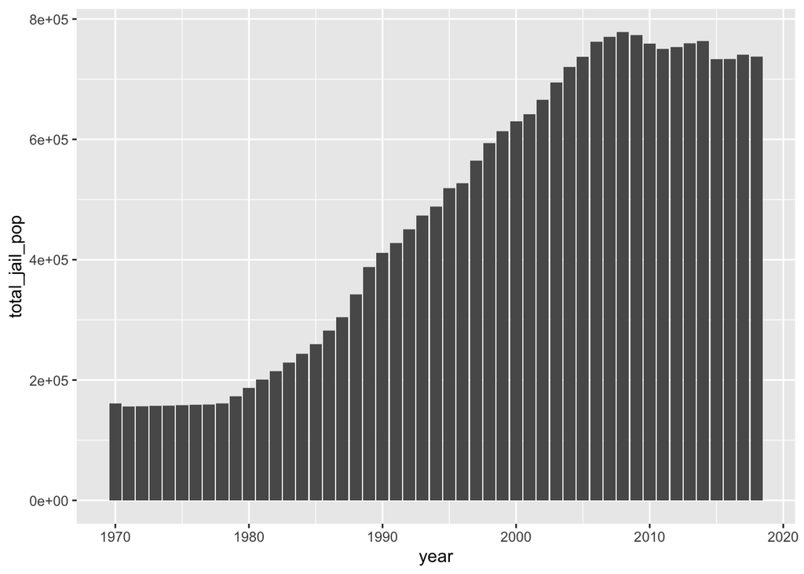

[figure not shown]

This graph shows us the incarceration trends in CA and WA. You can see that the WA trend seems to jump up and down and there is not a clear pattern. However, the overall pattern seems to be a slight decrease in the jail population in the years 2000-2010. For CA, the trend in the early 2000s seemed to be constant and then there was a sharp increase starting 2010.

## This chart tells us the percent change of women incarcerated per year.

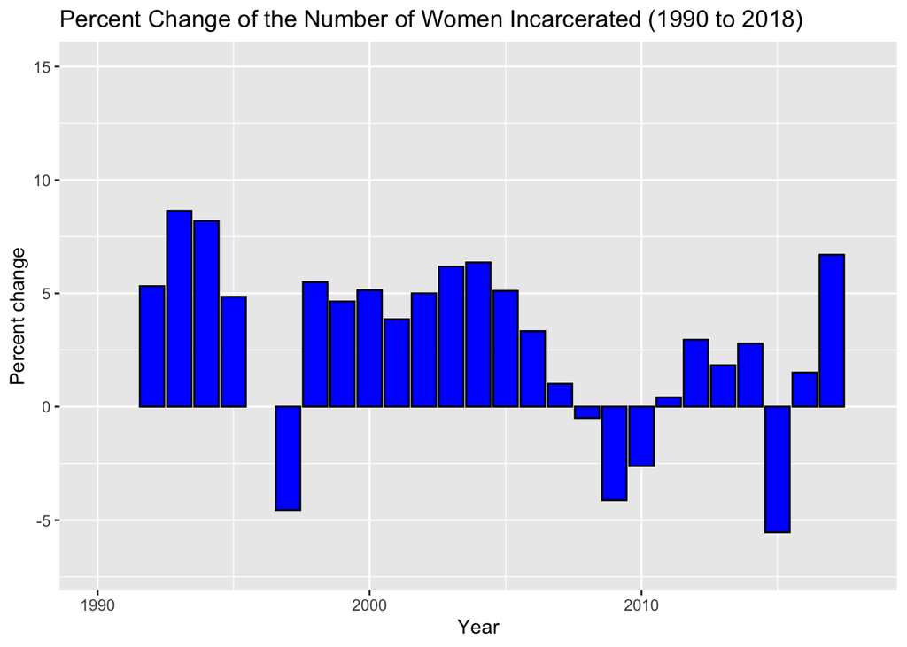

This graph focuses on the number of women that are incarcerated each year. Studying this minority group can be helpful for noticing patterns in incarceration trends. We can use this data to see if the two are connected: being a woman and incarceration. There seems to be a positive percent change for most years.

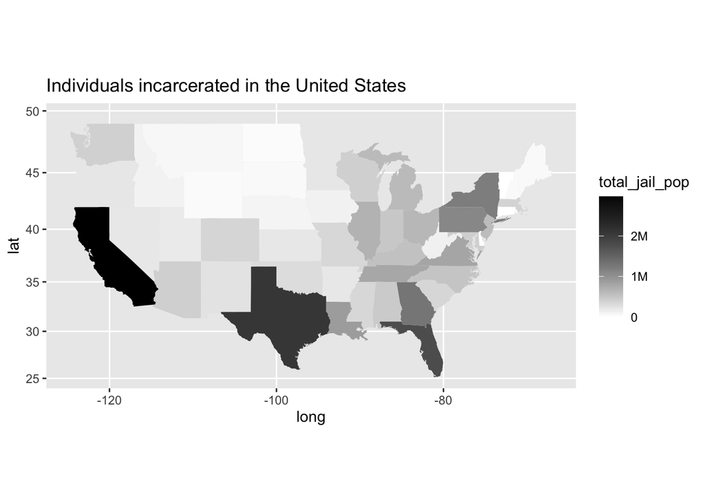

This map shows us areas of high incarceration rates. We can look at this map to see if certain areas have higher rates and why that may be the case. By looking at this map we can see that California has the highest jail population